# Danish Kings

Simon Larsen

2026-03-13

The task here is to load your Danish Monarchs csv into R using the `tidyverse` toolkit, calculate and explore the kings’ duration of reign with pipes `%>%` in `dplyr` and plot it over time.

## Load the kings

Make sure to first create an `.Rproj` workspace with a `data/` folder where you place either your own dataset or the provided `kings.csv` dataset.

1. Look at the dataset that are you loading and check what its columns are separated by? (hint: open it in plain text editor to see)

2. Create a `kings` object in R with the different functions below and inspect the different outputs.
- `read.csv()`
- `read_csv()`
- `read.csv2()`
- `read_csv2()`

```r
# FILL IN THE CODE BELOW and review the outputs
library(tidyverse)

view(kings4)

kings1 <- read.csv("data/Kongeraekker.CSV")

kings2 <- read_csv("data/Kongeraekker.CSV")

kings3 <- read.csv2("data/Kongeraekker.CSV", fileEncoding = "Latin1")

kings4 <- read_csv2("data/Konkeraekker.CSV")
```

Answer: **1. Which of these functions is a `tidyverse` function? Read data with it below into a `kings` object**

**2. What is the result of running `class()` on the `kings` object created with a tidyverse function.**

the class function shows that the kings data is a “data.frame”

**3. How many columns does the object have when created with these different functions?**

**4. Show the dataset so that we can see how R interprets each column** I have used the head(),tail() and glimpse() to show different parts of the data. The function to view the entire tabel is view().

```r
# COMPLETE THE BLANKS BELOW WITH YOUR CODE, then turn the 'eval' flag in this chunk to TRUE.
library(tidyverse)
kings <- read.csv2("data/Kongeraekker.CSV", fileEncoding = "Latin1")

class(kings)
```

```
## [1] "data.frame"
```

```r
ncol(kings)
```

```
## [1] 9
```

```r
head(kings)
```

```
##                Navn Fødselsår Fødselsår_usikkerhed Dødsår Dødsårs_usikkerhed
## 1    Gorm_den_Gamle   908-918                   ja    958                 ja
## 2 Harald_1._Blåtand       987                   ja     NA                 ja
## 3  Svend_1._Tveskæg      1014                   ja     NA                 ja
## 4         Harald_2.      <NA>                   ja   1018                 ja
## 5 Knud_1._den_Store       995                   ja   1035                nej
## 6         Hardeknud      1020                  nej   1042                nej
##   Regeringsstart Regeringsstart_usikkerhed Regeringsslut
## 1            936                       nej           958
## 2             NA                        ja           987
## 3             NA                        ja          1014
## 4           1014                       nej          1018
## 5           1018                       nej          1035
## 6           1035                       nej          1042
##   regeringsslut_usikkerhed
## 1                       ja
## 2                      nej
## 3                      nej
## 4                      nej
## 5                      nej
## 6                      nej
```

```r
tail(kings)
```

```
##             Navn Fødselsår Fødselsår_usikkerhed Dødsår Dødsårs_usikkerhed
## 44  Christian_9.      1818                  nej   1906                nej
## 45   Frederik_8.      1843                  nej   1912                nej
## 46 Christian_10.      1870                  nej   1947                nej
## 47   Frederik_9.      1899                  nej   1972                nej
## 48  Margrethe_2.      1940                  nej     NA                 ja
## 49  Frederik_10.      1968                  nej     NA                 ja
##    Regeringsstart Regeringsstart_usikkerhed Regeringsslut
## 44           1863                       nej          1906
## 45           1906                       nej          1912
## 46           1912                       nej          1947
## 47           1947                       nej          1972
## 48           1972                       nej          2024
## 49           2024                       nej            NA
##    regeringsslut_usikkerhed
## 44                      nej
## 45                      nej
## 46                      nej
## 47                      nej
## 48                      nej
## 49                       ja
```

```r
glimpse(kings)
```

```
## Rows: 49
## Columns: 9
## $ Navn                      <chr> "Gorm_den_Gamle", "Harald_1._Blåtand", "Sven…
## $ Fødselsår                 <chr> "908-918", "987", "1014", NA, "995", "1020",…
## $ Fødselsår_usikkerhed      <chr> "ja", "ja", "ja", "ja", "ja", "nej", "nej", …
## $ Dødsår                    <int> 958, NA, NA, 1018, 1035, 1042, 1047, NA, 108…
## $ Dødsårs_usikkerhed        <chr> "ja", "ja", "ja", "ja", "nej", "nej", "nej",…
## $ Regeringsstart            <int> 936, NA, NA, 1014, 1018, 1035, 1042, 1047, 1…
## $ Regeringsstart_usikkerhed <chr> "nej", "ja", "ja", "nej", "nej", "nej", "nej…
## $ Regeringsslut             <int> 958, 987, 1014, 1018, 1035, 1042, 1047, 1074…
## $ regeringsslut_usikkerhed  <chr> "ja", "nej", "nej", "nej", "nej", "nej", "ne…
```

## Calculate the duration of reign for all the kings in your table

To calculate the duration of reign for all Danish monarchs, we first marked the two columns reign_start and reign_end as numeric values. This allowed us to perform calculations using the data.

We then created a new column called reign_duration. The duration of each reign was calculated by subtracting the start year of the reign from the end year. This made it possible to see how long each monarch ruled.

In order to make the calculation, we marked the two columns reign_start and reign_end as numeric.

```r
library(tidyverse)


kings$Regeringsstart <- as.numeric(kings$Regeringsstart)
kings$Regeringsslut <- as.numeric(kings$Regeringsslut)


kings <- kings %>%
  mutate(reign_duration=Regeringsslut - Regeringsstart)
```

## Calculate the average duration of reign for all rulers

To calculate the average duration of reign among Danish monarchs, we used the mean() function and applied it to the reign_duration column. The argument na.rm = TRUE was included to remove any missing values before calculating the mean. This ensured that incomplete observations did not affect the result.

```r
library(tidyverse)

average <- mean(kings$reign_duration,na.rm=TRUE)


kings %>%
  summarize(mean_reign_duration=mean(reign_duration,na.rm=TRUE))
```

```
##   mean_reign_duration
## 1            18.93478
```

## How many and which kings enjoyed a longer-than-average duration of reign?

To answer this question, we filtered the dataset to identify monarchs whose reign_duration was greater than the calculated average. This was done using the filter() function.

```r
library(tidyverse)

kings %>%
  filter(reign_duration>average) %>%
  count()
```

```
##    n
## 1 21
```

## How many days did the three longest-ruling monarchs rule?

To answer this question, we went through a couple of steps. First, we sorted the variable reign_duration in descending order. This made it possible to identify the monarchs with the longest reigns. Then we selected the three longest-ruling monarchs, and we converted the reign duration from years to days by multiplying the number of years by 365.25.

The three longest-ruling monarchs were then selected, and their reign durations were converted from years to days by multiplying the number of years by 365.25. This provided an approximate estimate of how many days each monarch ruled.

```r
library(tidyverse)
library(dplyr)

kings_sorted <- kings %>%
  arrange(desc(reign_duration))

top3 <- kings_sorted %>%
  slice(1:3)

top3 <- top3 %>%
  mutate(Days=reign_duration*365.25)

top3 <- top3 %>% relocate(last_col(), .after = 1)


top3
```

```
##                 Navn     Days Fødselsår Fødselsår_usikkerhed Dødsår
## 1       Margrethe_2. 18993.00      1940                  nej     NA
## 2 Erik_7._af_Pommern 15705.75      1382                   ja   1459
## 3       Christian_9. 15705.75      1818                  nej   1906
##   Dødsårs_usikkerhed Regeringsstart Regeringsstart_usikkerhed Regeringsslut
## 1                 ja           1972                       nej          2024
## 2                nej           1396                       nej          1439
## 3                nej           1863                       nej          1906
##   regeringsslut_usikkerhed reign_duration
## 1                      nej             52
## 2                      nej             43
## 3                      nej             43
```

## Challenge: Plot the kings’ duration of reign through time

“To visualize how the duration of Danish monarchs’ reigns changes over time, we created a scatterplot using the ggplot2 package. Each point represents a monarch, where the x-axis shows the period of the reign (using the midpoint of the reign), and the y-axis shows the duration of the reign in years.

This visualization allows us to identify patterns or trends in how long monarchs ruled across different historical periods.”

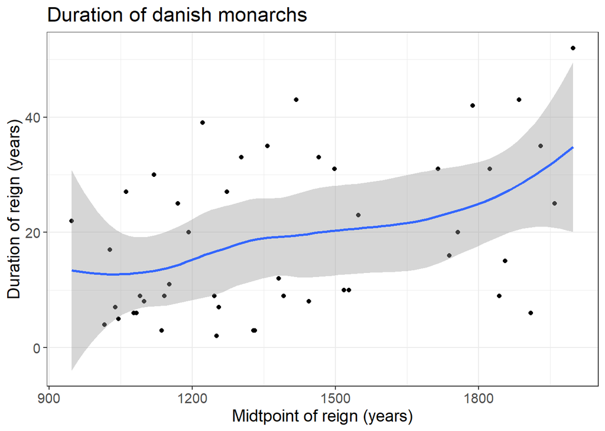

```r
library(tidyverse)
kings <- kings %>%
  mutate(midyear=Regeringsstart+(Regeringsslut - Regeringsstart)/2)

library(ggplot2)

ggplot(kings,aes(x=midyear, y=reign_duration))+
  geom_point()+
  geom_smooth()+
  labs(
    title = "Duration of danish monarchs",
    x = "Midtpoint of reign (years)",
    y = "Duration of reign (years)"
  )+
  theme_bw()+
  theme(text=element_text(size = 14))
```